# Elias 3o4p ASP 229_0_0.1_8

10/81

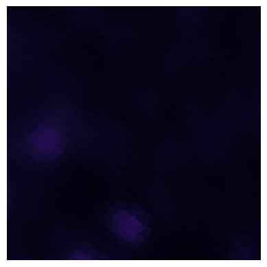

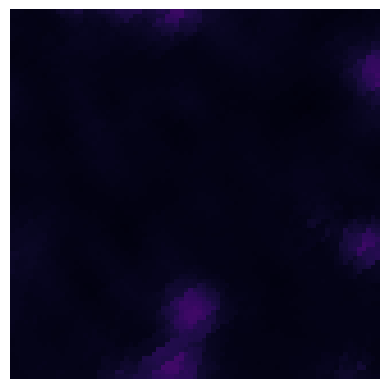

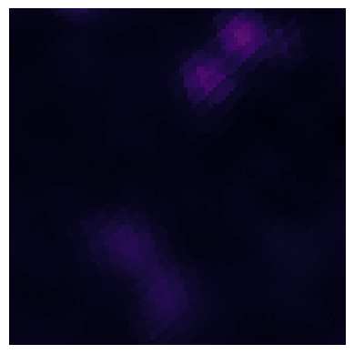

11/81

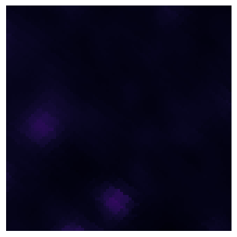

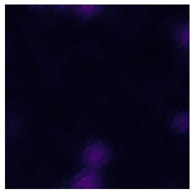

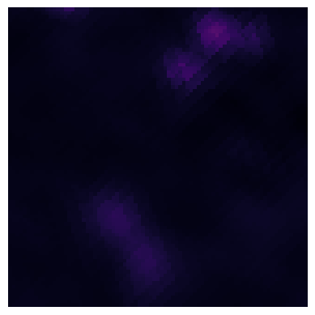

12/81

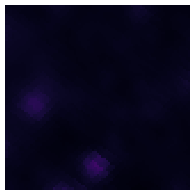

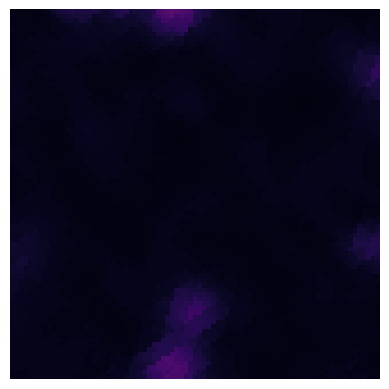

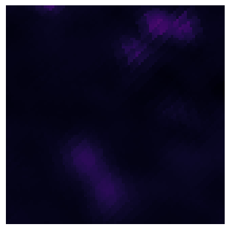

13/81

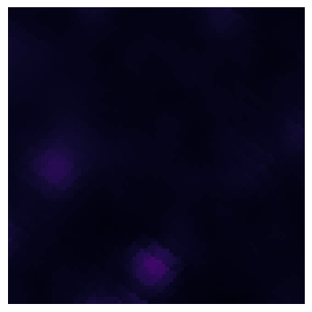

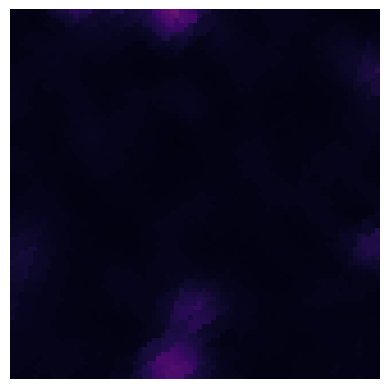

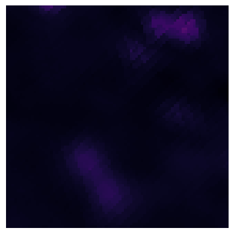

14/81

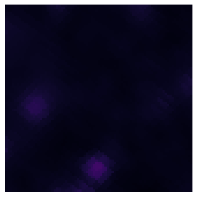

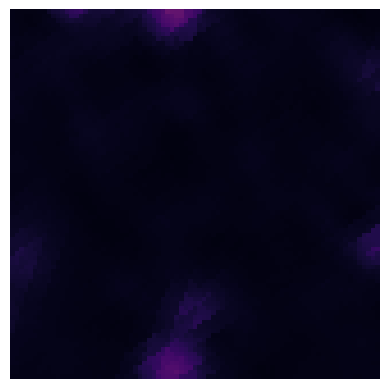

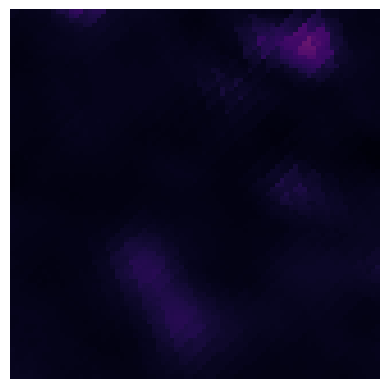

15/81

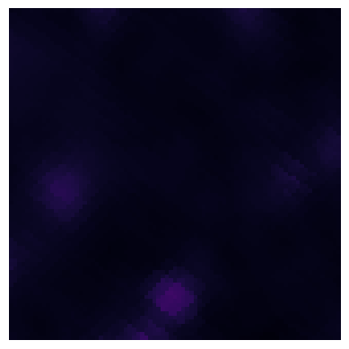

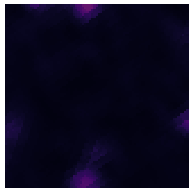

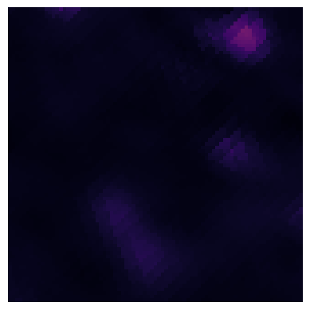

16/81

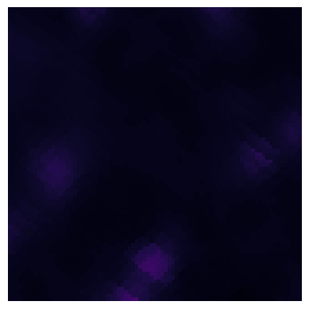

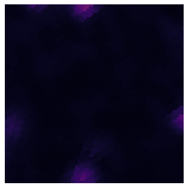

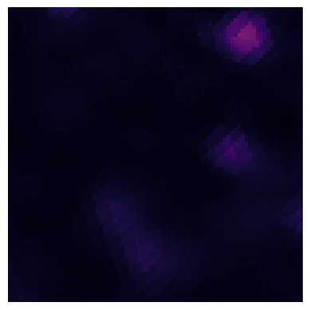

17/81

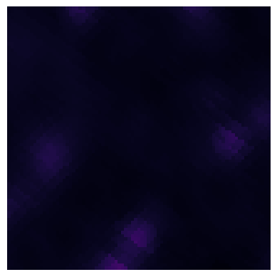

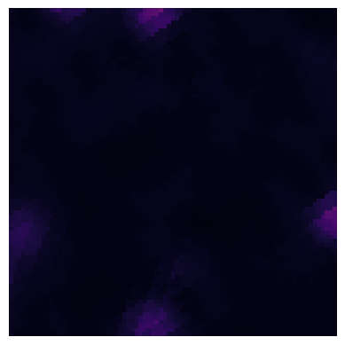

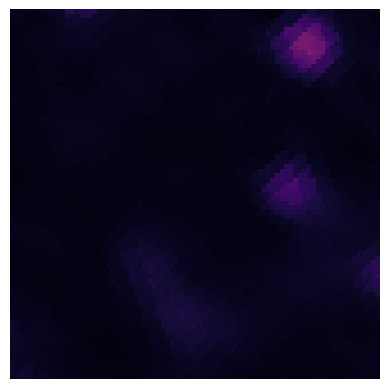

18/81

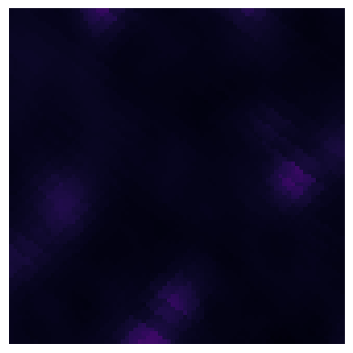

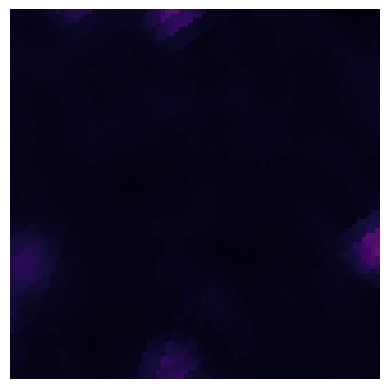

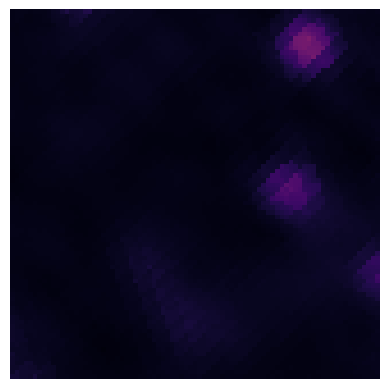

19/81

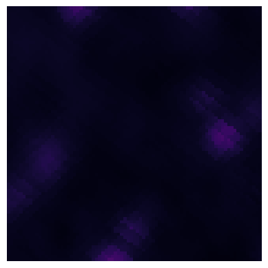

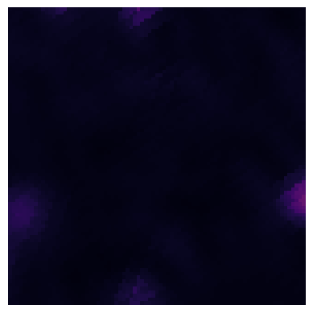

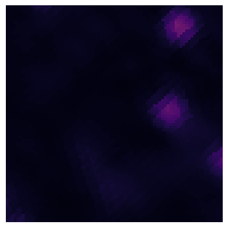

20/81

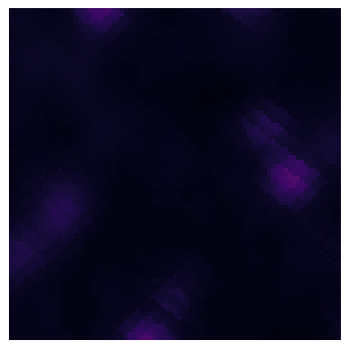

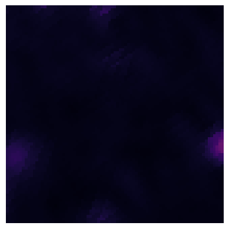

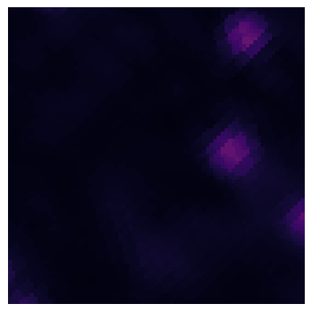

21/81

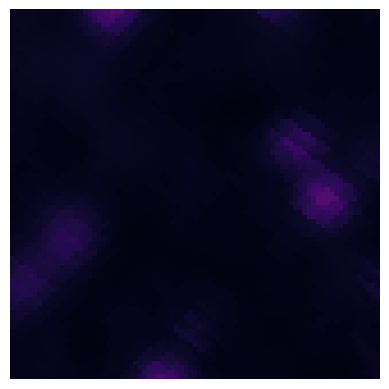

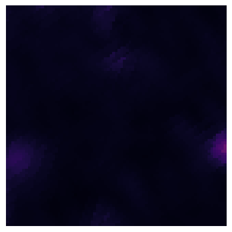

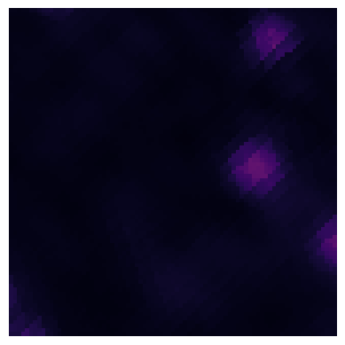

22/81

22/81

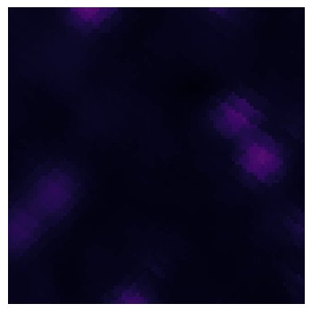

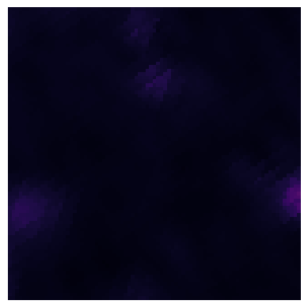

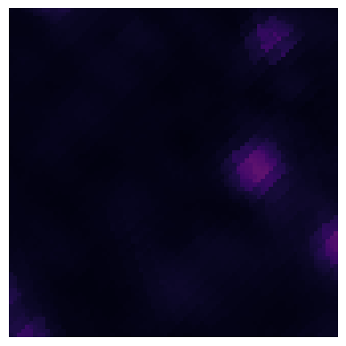

23/81

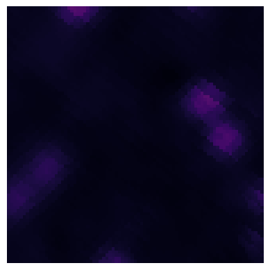

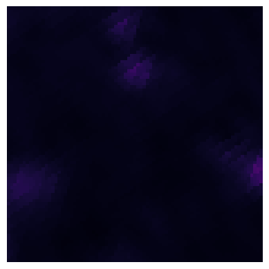

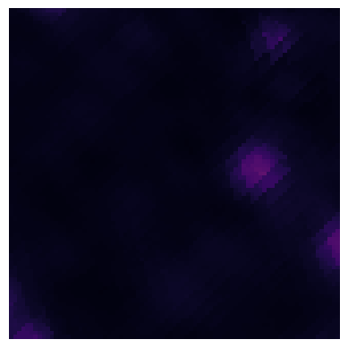

24/81

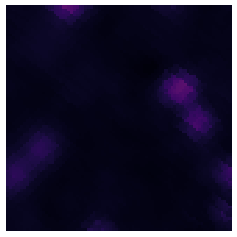

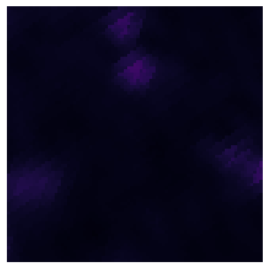

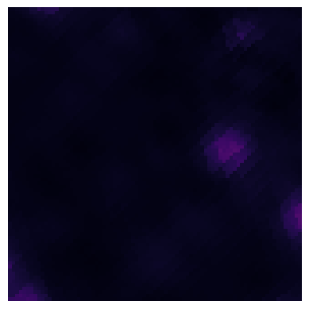

25/81

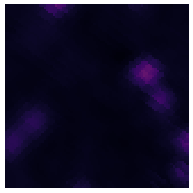

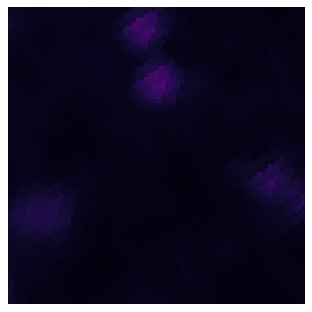

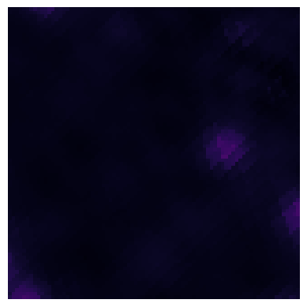

26/81

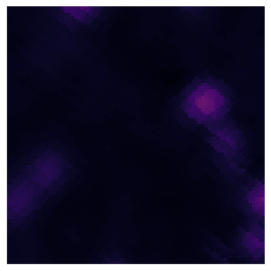

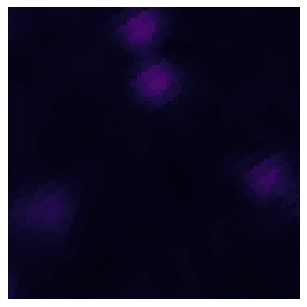

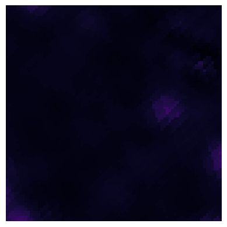

27/81

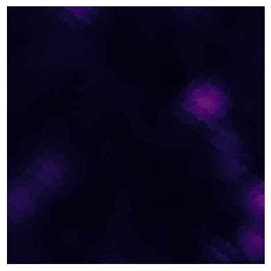

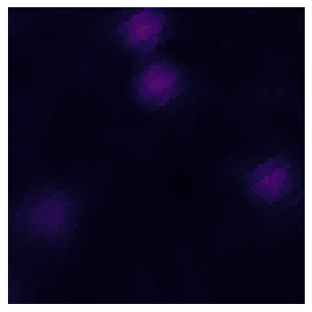

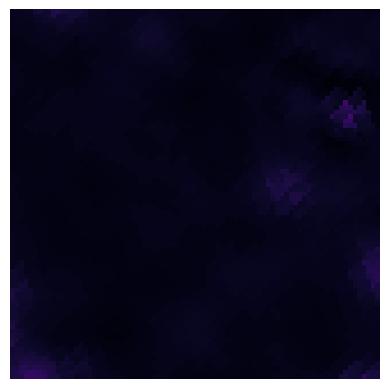

28/81

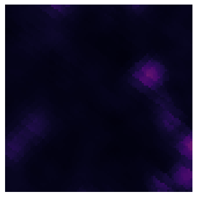

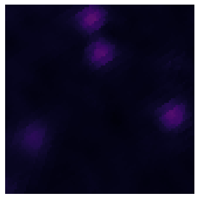

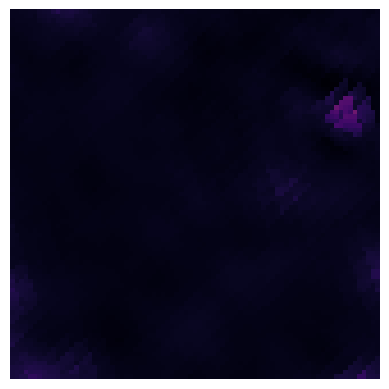

29/81

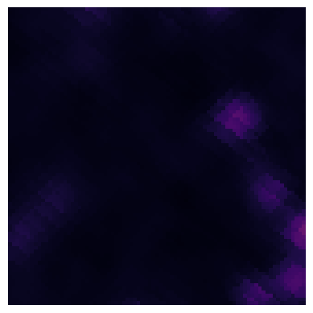

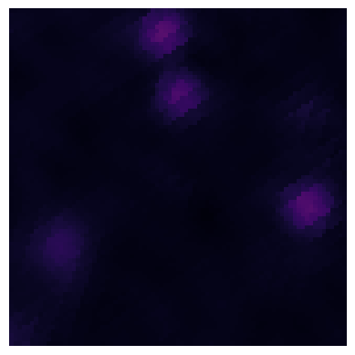

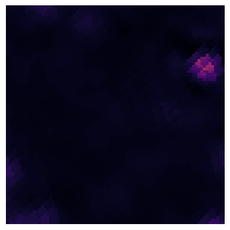

30/81